# 4 Clustering and classification

## 4.1. Boston dataset from MASS package

```r
#Load the Rquired (usual) libraries
library(MASS)
library(reshape2)
```

```r
library(ggplot2)
library(GGally)
library(dplyr)
library(corrplot)
library(tidyverse)
#load the Boston Data
data("Boston")
```

## 4.2. Boston Dataset

Load Boston data from the MASS package in R. The data is described in R documentation [here](https://stat.ethz.ch/R-manual/R-devel/library/MASS/html/Boston.html). This is related to real estate details from Boston suburban area.

- 506 observations of 14 different parameters.
- It contains following columns **crim : per capita crime rate by town.** zn: proportion of residential land zoned for lots over 25,000 sq.ft. **indus: proportion of non-retail business acres per town.** chas: Charles River dummy variable (= 1 if tract bounds river; 0 otherwise). **nox: nitrogen oxides concentration (parts per 10 million).** rm: average number of rooms per dwelling. **age:proportion of owner-occupied units built prior to 1940.** dis:weighted mean of distances to five Boston employment centres. **rad:index of accessibility to radial highways.** tax:full-value property-tax rate per $10,000. **ptratio: pupil-teacher ratio by town.** black: 1000(Bk - 0.63)^2 where Bk is the proportion of blacks by town. **lstat: lower status of the population (percent).** medv: median value of owner-occupied homes in $1000s.

We will focus on the Crime rate and look at the data available.

```r
str(Boston)
```

```
## 'data.frame':    506 obs. of  14 variables:
##  $ crim   : num  0.00632 0.02731 0.02729 0.03237 0.06905 ...
##  $ zn     : num  18 0 0 0 0 0 12.5 12.5 12.5 12.5 ...
##  $ indus  : num  2.31 7.07 7.07 2.18 2.18 2.18 7.87 7.87 7.87 7.87 ...
##  $ chas   : int  0 0 0 0 0 0 0 0 0 0 ...
##  $ nox    : num  0.538 0.469 0.469 0.458 0.458 0.458 0.524 0.524 0.524 0.524 ...
##  $ rm     : num  6.58 6.42 7.18 7 7.15 ...
##  $ age    : num  65.2 78.9 61.1 45.8 54.2 58.7 66.6 96.1 100 85.9 ...
##  $ dis    : num  4.09 4.97 4.97 6.06 6.06 ...
##  $ rad    : int  1 2 2 3 3 3 5 5 5 5 ...
##  $ tax    : num  296 242 242 222 222 222 311 311 311 311 ...
##  $ ptratio: num  15.3 17.8 17.8 18.7 18.7 18.7 15.2 15.2 15.2 15.2 ...
##  $ black  : num  397 397 393 395 397 ...
##  $ lstat  : num  4.98 9.14 4.03 2.94 5.33 ...
##  $ medv   : num  24 21.6 34.7 33.4 36.2 28.7 22.9 27.1 16.5 18.9 ...
```

```r
summary(Boston)
```

```
##       crim                zn             indus            chas
##  Min.   : 0.00632   Min.   :  0.00   Min.   : 0.46   Min.   :0.00000
##  1st Qu.: 0.08204   1st Qu.:  0.00   1st Qu.: 5.19   1st Qu.:0.00000
##  Median : 0.25651   Median :  0.00   Median : 9.69   Median :0.00000
##  Mean   : 3.61352   Mean   : 11.36   Mean   :11.14   Mean   :0.06917
##  3rd Qu.: 3.67708   3rd Qu.: 12.50   3rd Qu.:18.10   3rd Qu.:0.00000
##  Max.   :88.97620   Max.   :100.00   Max.   :27.74   Max.   :1.00000
##       nox               rm             age              dis
##  Min.   :0.3850   Min.   :3.561   Min.   :  2.90   Min.   : 1.130
##  1st Qu.:0.4490   1st Qu.:5.886   1st Qu.: 45.02   1st Qu.: 2.100
##  Median :0.5380   Median :6.208   Median : 77.50   Median : 3.207
##  Mean   :0.5547   Mean   :6.285   Mean   : 68.57   Mean   : 3.795
##  3rd Qu.:0.6240   3rd Qu.:6.623   3rd Qu.: 94.08   3rd Qu.: 5.188
##  Max.   :0.8710   Max.   :8.780   Max.   :100.00   Max.   :12.127
##       rad              tax           ptratio          black
##  Min.   : 1.000   Min.   :187.0   Min.   :12.60   Min.   :  0.32
##  1st Qu.: 4.000   1st Qu.:279.0   1st Qu.:17.40   1st Qu.:375.38
##  Median : 5.000   Median :330.0   Median :19.05   Median :391.44
##  Mean   : 9.549   Mean   :408.2   Mean   :18.46   Mean   :356.67
##  3rd Qu.:24.000   3rd Qu.:666.0   3rd Qu.:20.20   3rd Qu.:396.23
##  Max.   :24.000   Max.   :711.0   Max.   :22.00   Max.   :396.90
##      lstat            medv
##  Min.   : 1.73   Min.   : 5.00
##  1st Qu.: 6.95   1st Qu.:17.02
##  Median :11.36   Median :21.20
##  Mean   :12.65   Mean   :22.53
##  3rd Qu.:16.95   3rd Qu.:25.00
##  Max.   :37.97   Max.   :50.00
```

```r
glimpse(Boston)
```

```
## Observations: 506
## Variables: 14
## $ crim    <dbl> 0.00632, 0.02731, 0.02729, 0.03237, 0.06905, 0.02985, ...
## $ zn      <dbl> 18.0, 0.0, 0.0, 0.0, 0.0, 0.0, 12.5, 12.5, 12.5, 12.5,...
## $ indus   <dbl> 2.31, 7.07, 7.07, 2.18, 2.18, 2.18, 7.87, 7.87, 7.87, ...
## $ chas    <int> 0, 0, 0, 0, 0, 0, 0, 0, 0, 0, 0, 0, 0, 0, 0, 0, 0, 0, ...
## $ nox     <dbl> 0.538, 0.469, 0.469, 0.458, 0.458, 0.458, 0.524, 0.524...
## $ rm      <dbl> 6.575, 6.421, 7.185, 6.998, 7.147, 6.430, 6.012, 6.172...
## $ age     <dbl> 65.2, 78.9, 61.1, 45.8, 54.2, 58.7, 66.6, 96.1, 100.0,...
## $ dis     <dbl> 4.0900, 4.9671, 4.9671, 6.0622, 6.0622, 6.0622, 5.5605...
## $ rad     <int> 1, 2, 2, 3, 3, 3, 5, 5, 5, 5, 5, 5, 5, 4, 4, 4, 4, 4, ...
## $ tax     <dbl> 296, 242, 242, 222, 222, 222, 311, 311, 311, 311, 311,...
## $ ptratio <dbl> 15.3, 17.8, 17.8, 18.7, 18.7, 18.7, 15.2, 15.2, 15.2, ...
## $ black   <dbl> 396.90, 396.90, 392.83, 394.63, 396.90, 394.12, 395.60...
## $ lstat   <dbl> 4.98, 9.14, 4.03, 2.94, 5.33, 5.21, 12.43, 19.15, 29.9...
## $ medv    <dbl> 24.0, 21.6, 34.7, 33.4, 36.2, 28.7, 22.9, 27.1, 16.5, ...
```

## 4.3. Boston Dataset : Graphical Overview

[output not shown]

[output not shown]

- Graphical Representation of Correlation Plots in matrix format.

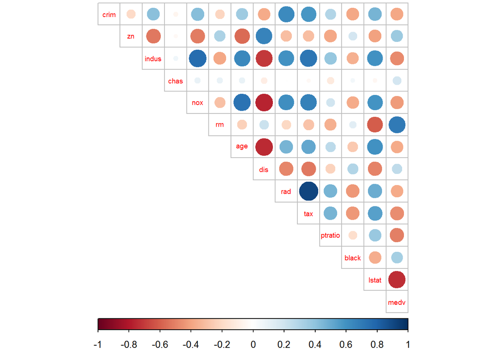

```r
library(corrplot)
corrplot(cor_matrix, method="circle", type = "upper", cl.pos = "b", tl.pos = "d", tl.cex = 0.6)
```

## 4.4 Standardization of data

In the scaling we subtract the column means from the corresponding columns and divide the difference with standard deviation.

We can use the scale function to scale Boston Data set

```r
boston_scaled <- scale(Boston, center = TRUE, scale = TRUE)
summary(boston_scaled)
```

```
##       crim                 zn               indus
##  Min.   :-0.419367   Min.   :-0.48724   Min.   :-1.5563
##  1st Qu.:-0.410563   1st Qu.:-0.48724   1st Qu.:-0.8668
##  Median :-0.390280   Median :-0.48724   Median :-0.2109
##  Mean   : 0.000000   Mean   : 0.00000   Mean   : 0.0000
##  3rd Qu.: 0.007389   3rd Qu.: 0.04872   3rd Qu.: 1.0150
##  Max.   : 9.924110   Max.   : 3.80047   Max.   : 2.4202
##       chas              nox                rm               age
##  Min.   :-0.2723   Min.   :-1.4644   Min.   :-3.8764   Min.   :-2.3331
##  1st Qu.:-0.2723   1st Qu.:-0.9121   1st Qu.:-0.5681   1st Qu.:-0.8366
##  Median :-0.2723   Median :-0.1441   Median :-0.1084   Median : 0.3171
##  Mean   : 0.0000   Mean   : 0.0000   Mean   : 0.0000   Mean   : 0.0000
##  3rd Qu.:-0.2723   3rd Qu.: 0.5981   3rd Qu.: 0.4823   3rd Qu.: 0.9059
##  Max.   : 3.6648   Max.   : 2.7296   Max.   : 3.5515   Max.   : 1.1164
##       dis               rad               tax             ptratio
##  Min.   :-1.2658   Min.   :-0.9819   Min.   :-1.3127   Min.   :-2.7047
##  1st Qu.:-0.8049   1st Qu.:-0.6373   1st Qu.:-0.7668   1st Qu.:-0.4876
##  Median :-0.2790   Median :-0.5225   Median :-0.4642   Median : 0.2746
##  Mean   : 0.0000   Mean   : 0.0000   Mean   : 0.0000   Mean   : 0.0000
##  3rd Qu.: 0.6617   3rd Qu.: 1.6596   3rd Qu.: 1.5294   3rd Qu.: 0.8058
##  Max.   : 3.9566   Max.   : 1.6596   Max.   : 1.7964   Max.   : 1.6372
##      black             lstat              medv
##  Min.   :-3.9033   Min.   :-1.5296   Min.   :-1.9063
##  1st Qu.: 0.2049   1st Qu.:-0.7986   1st Qu.:-0.5989
##  Median : 0.3808   Median :-0.1811   Median :-0.1449
##  Mean   : 0.0000   Mean   : 0.0000   Mean   : 0.0000
##  3rd Qu.: 0.4332   3rd Qu.: 0.6024   3rd Qu.: 0.2683
##  Max.   : 0.4406   Max.   : 3.5453   Max.   : 2.9865
```

*Scaling helps in comparing values in different ranges.* We can see that all the columns are now in the same scale and Mean is zero for all the columns.

## 4.4. Linear Discriminant Analysis

*Linear Discriminant analysis is a classification (and dimension reduction) method. It finds the (linear) combination of the variables that separate the target variable classes. The target can be binary or multiclass variable.

- We first convert the variable into a categorical variable with values “low”, “med_low”, “med_high”, “high”. We define this vector using quantile() function, executed on scaled continues variable crime.

```r
boston_scaled <- scale(Boston, center = TRUE, scale = TRUE)
class(boston_scaled)
```

```
## [1] "matrix"
```

```r
boston_scaled <- as.data.frame(boston_scaled)
scaled_crim <- boston_scaled$crim
summary(scaled_crim)
```

```
##      Min.   1st Qu.    Median      Mean   3rd Qu.      Max.
## -0.419400 -0.410600 -0.390300  0.000000  0.007389  9.924000
```

```r
bins <- quantile(scaled_crim)
bins
```

```
##           0%          25%          50%          75%         100%
## -0.419366929 -0.410563278 -0.390280295  0.007389247  9.924109610
```

```r
crime <- cut(scaled_crim, breaks = bins, labels = c("low", "med_low", "med_high", "high"), include.lowest = TRUE)
```

*We divide the data to training sets and test sets with a share of 80%.* We choose randomly 80% of the rows for the training set, and rest of the data for testing.

```r
n <- nrow(boston_scaled)
ind <- sample(n,  size = n * 0.8)
train <- boston_scaled[ind,]
test <- boston_scaled[-ind,]
```

## 4.5 LDA modeling using training data

Linear discriminant model on training data

```r
lda.fit <- lda(crime ~ ., data = train)
lda.fit
```

```
## Call:
## lda(crime ~ ., data = train)
##
## Prior probabilities of groups:
##       low   med_low  med_high      high
## 0.2400990 0.2475248 0.2599010 0.2524752
##
## Group means:
##                  zn      indus         chas        nox          rm
## low       1.0994349 -0.9789817 -0.069385757 -0.9029715  0.46690625
## med_low  -0.0811937 -0.3284931  0.003267949 -0.5743562 -0.12247693
## med_high -0.3794348  0.1507742  0.290113823  0.3790548  0.07634571
## high     -0.4872402  1.0171096 -0.040734936  1.1226429 -0.50884973
##                 age        dis        rad        tax     ptratio
## low      -0.9385175  0.9475446 -0.6870585 -0.7411873 -0.49231857
## med_low  -0.4460536  0.3469035 -0.5385629 -0.4798181 -0.01410363
## med_high  0.4004003 -0.3699419 -0.4568577 -0.3566207 -0.32347026
## high      0.8155382 -0.8630308  1.6382099  1.5141140  0.78087177
##               black       lstat         medv
## low       0.3795924 -0.78738349  0.562388798
## med_low   0.3118956 -0.19308939 -0.008677332
## med_high  0.1080629  0.04035462  0.169054597
## high     -0.7428731  0.90351200 -0.721930404
##
## Coefficients of linear discriminants:
##                  LD1         LD2         LD3
## zn       0.104227392  0.70080440 -0.96593702
## indus    0.115962232 -0.31697564  0.27539335
## chas    -0.106134335 -0.05641377  0.06624965
## nox      0.350684114 -0.62945932 -1.23274739
## rm      -0.143941608 -0.11249576 -0.13245324
## age      0.108620324 -0.33808112 -0.32803217
## dis     -0.081273101 -0.23295680  0.07897593
## rad      3.676952410  0.94413673 -0.16149820
## tax     -0.005866422  0.05991961  0.67242794
## ptratio  0.106554627 -0.01252038 -0.16891769
## black   -0.121089806  0.05457189  0.13655475
## lstat    0.209213862 -0.26705294  0.12618304
## medv     0.200934507 -0.34787549 -0.31114803
##
## Proportion of trace:
##    LD1    LD2    LD3
## 0.9541 0.0351 0.0108
```

*Next we visualize results by using biplot function.* The argument *dimen* in **plot()** function determines how many discriminants are used.

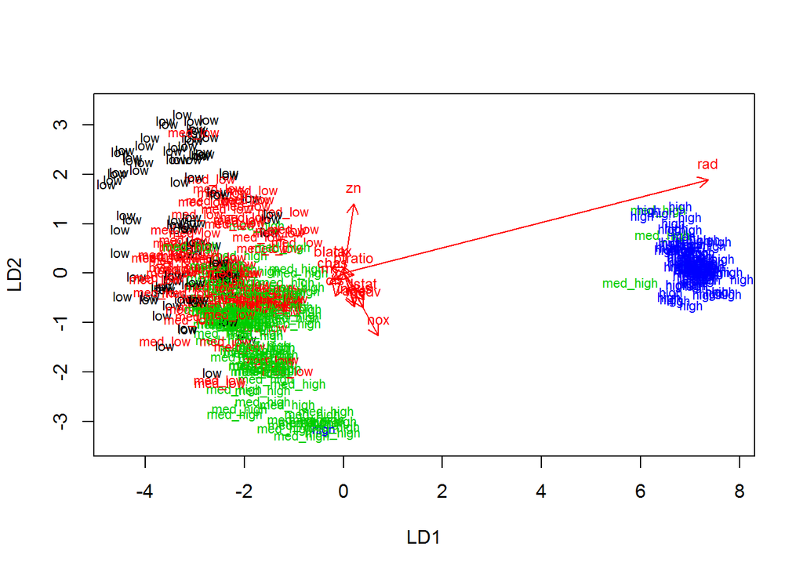

```r
lda.fit <- lda(crime ~ ., data = train)

lda.arrows <- function(x, myscale = 1, arrow_heads = 0.1, color = "red", tex = 0.75, choices = c(1,2)){
  heads <- coef(x)
  arrows(x0 = 0, y0 = 0,
         x1 = myscale * heads[,choices[1]],
         y1 = myscale * heads[,choices[2]], col=color, length = arrow_heads)
  text(myscale * heads[,choices], labels = row.names(heads),
       cex = tex, col=color, pos=3)
}

classes <- as.numeric(train$crime)

plot(lda.fit, dimen = 2, col = classes, pch = classes)
lda.arrows(lda.fit, myscale = 2)
```

## 4.6 LDA for prediction: use of test data.

*Prediction of the LDA model to classify the test data.* In order to analyze the model performance we use cross tabulation and create a table consisting of correct and predicted classes.

```r
lda.pred <- predict(lda.fit, newdata = test)
table(correct = test$crime, predicted = lda.pred$class)
```

```
##           predicted
## correct    low med_low med_high high
##   low       13      15        2    0
##   med_low    2      18        6    0
##   med_high   0       2       16    3
##   high       0       0        0   25
```

We can use table() function to produce a matrix in order to determine how many observations were correctly or incorrectly classified.

## 4.7 Distance measures and clustering. K-means algorithm

- In clustering the number of classes is unknown, and the data are grouped based on their similarity.
- Standardize Boston Data Boston data.
- Eucledian distance in the dist() function creates a distance matrix consisting of pairwise distances of the observations.

```r
dist_eu <- dist(boston_scaled, method = "euclidean")
summary(dist_eu)
```

```
##    Min. 1st Qu.  Median    Mean 3rd Qu.    Max.
##  0.1394  3.5270  4.9080  4.9390  6.2420 13.0000
```

K-means kmeans()is an unsupervised method, that assigns observations to groups or clusters based on similarity of the objects. It takes as an argument the number of clusters to look:

One way to determine the number of clusters is to look at how the total of within cluster sum of squares (WCSS) behaves when the number of cluster changes. The optimal number of clusters is achieved when WCSS drops significantly.

The total within sum of squares twcss is defined below. K-means randomly assigns the initial cluster centers using the function set.seed() which might generate minor differences in the plots.

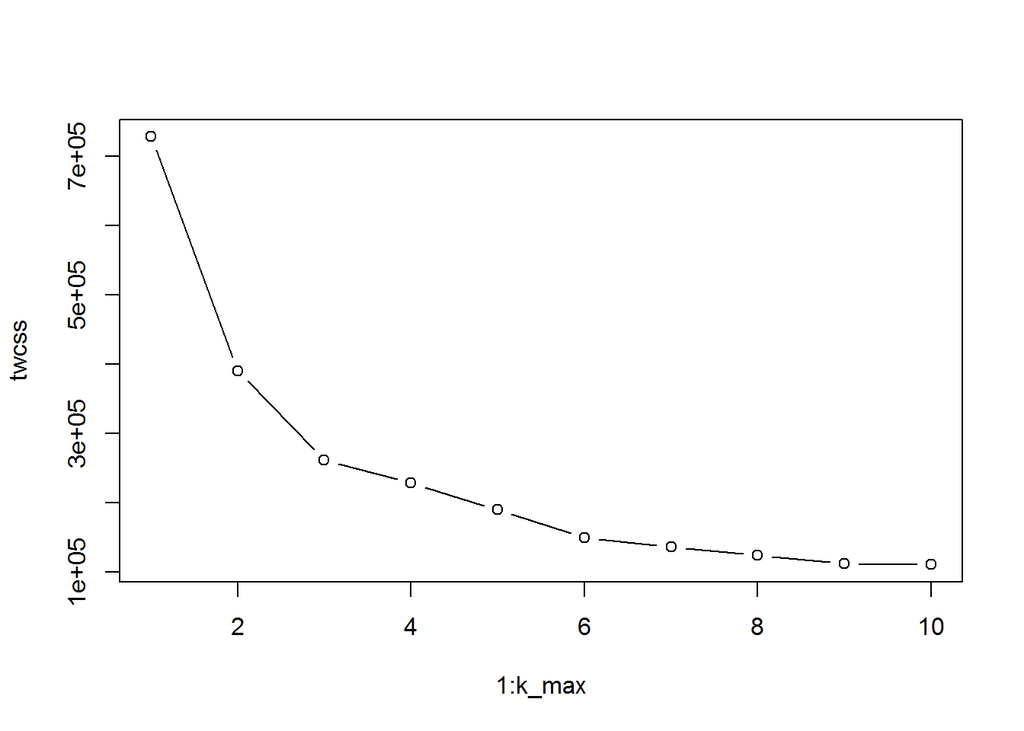

```r
set.seed(123)
k_max <- 10
twcss <- sapply(1:k_max, function(k){kmeans(dist_eu, k)$tot.withinss})
plot(1:k_max, twcss, type='b')
```

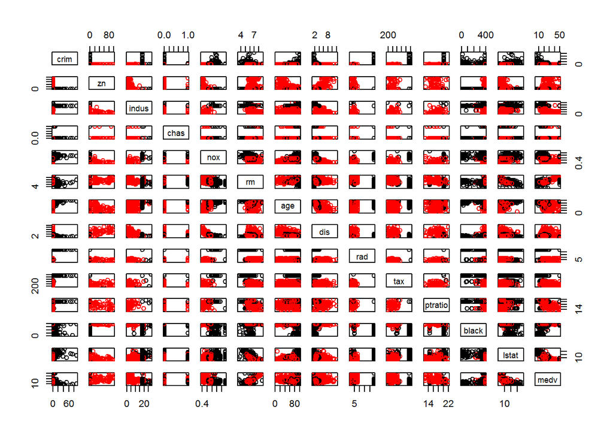

```r
km <-kmeans(dist_eu, centers = 2)
pairs(Boston, col = km$cluster)
```

The results show that twcss drops significantly at k=2. On the last graphics we calculate and plot **kmeans** function for 2 clusters because it is easier to show.

## 4.Bonus.1

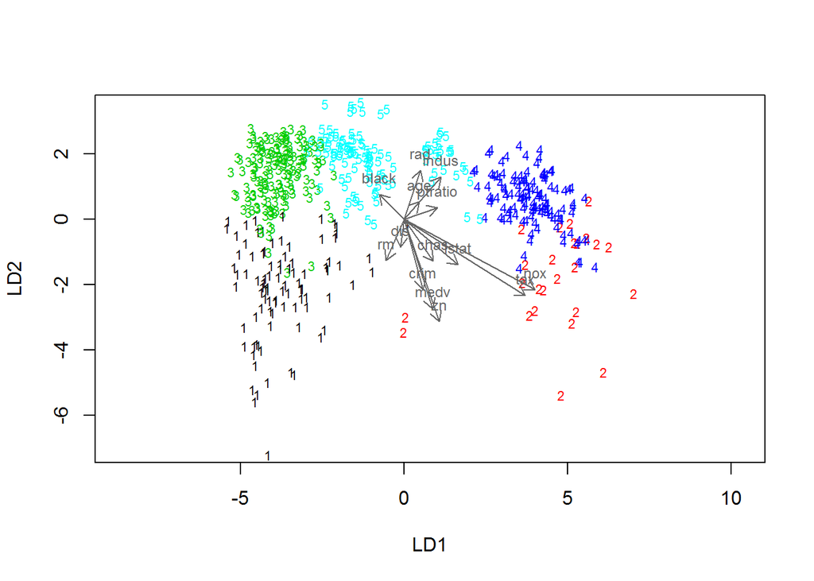

```r
set.seed(123)
data("Boston")
boston_scaled2 <- as.data.frame(scale(Boston, center = TRUE, scale = TRUE))
dist_eu2 <- dist(boston_scaled2, method = "euclidean")
km2 <- kmeans(dist_eu2, centers = 5)
boston_scaled2$cluster <- km2$cluster
lda.fit2 <- lda(cluster ~ ., data =boston_scaled2)
plot(lda.fit2, col=as.numeric(boston_scaled2$cluster), dimen=2)
lda.arrows(lda.fit2, myscale = 3, col = "#666666")
```

## 4.Bonus.2

```r
library(plotly)
model_predictors <- dplyr::select(train, -crime)

dim(model_predictors)
```

```
## [1] 404  13
```

```r
dim(lda.fit$scaling)
```

```
## [1] 13  3
```

```r
matrix_product <- as.matrix(model_predictors) %*% lda.fit$scaling
matrix_product <- as.data.frame(matrix_product)
plot_ly(x = matrix_product$LD1, y = matrix_product$LD2, z = matrix_product$LD3, type= 'scatter3d', mode='markers', color=train$crime)
```

[interactive chart not shown]

```r
train$cluster <- boston_scaled2$cluster[match(rownames(train), rownames(boston_scaled2))]
plot_ly(x = matrix_product$LD1, y = matrix_product$LD2, z = matrix_product$LD3, type= 'scatter3d', mode='markers', color=as.factor(train$cluster))
```

[interactive chart not shown]